# Open Meteo Weather Exploration

davegoblue

2023-09-29

## Background

Open-Meteo maintains an [API for historical weather](https://open-meteo.com/en/docs/historical-weather-api) that allows for non-commercial usage of historical weather data maintained by the website.

This file builds on _v001 to run exploratory analysis on some historical weather data.

## Functions and Libraries

The exploration process uses tidyverse, several generic custom functions, and several functions specific to Open Meteo processing. First, tidyverse and the generic functions are loaded:

```r
library(tidyverse) # tidyverse functionality is included throughout
source("./Generic_Added_Utility_Functions_202105_v001.R") # Basic functions
```

Next, specific functions written in _v001 are copied:

```r
# Helper function for reading a partial CSV file
partialCSVRead <- function(loc, firstRow=1L, lastRow=+Inf, col_names=TRUE, ...) {

    # FUNCTION arguments
    # loc: file location
    # firstRow: first row that is relevant to the partial file read (whether header line or data line)
    # last Row: last row that is relevant to the partial file read (+Inf means read until last line of file)
    # col_names: the col_names parameter passed to readr::read_csv
    #            TRUE means header=TRUE (get column names from file, read data starting on next line)
    #            FALSE means header=FALSE (auto-generate column names, read data starting on first line)
    #            character vector means use these as column names (read data starting on first line)
    # ...: additional arguments passed to read_csv

    # Read the file and return
    # skip: rows to be skipped are all those prior to firstRow
    # n_max: maximum rows read are lastRow-firstRow, with an additional data row when col_names is not TRUE
    readr::read_csv(loc,
                    col_names=col_names,
                    skip=firstRow-1,
                    n_max=lastRow-firstRow+ifelse(isTRUE(col_names), 0, 1),
                    ...
                    )

}


# Get the break points for gaps in a vector (e.g., 0, 3, 5:8, 20 has break points 0, 3, 5, 20 and 0, 3, 8, 30)
vecGaps <- function(x, addElements=c(), sortUnique=TRUE) {

    if(length(addElements)>0) x <- c(addElements, x)
    if(isTRUE(sortUnique)) x <- unique(sort(x))
    list("starts"=c(x[is.na(lag(x)) | x-lag(x)>1], +Inf),
         "ends"=x[is.na(lead(x)) | lead(x)-x>1]
         )

}


# Find the break points in a single file
flatFileGaps <- function(loc) {

    which(stringr::str_length(readLines(loc))==0) %>% vecGaps(addElements=0)

}


# Read all relevant data as CSV with header
readMultiCSV <- function(loc, col_names=TRUE, ...) {

    gaps <- flatFileGaps(loc)

    lapply(seq_along(gaps$ends),
           FUN=function(x) partialCSVRead(loc,
                                          firstRow=gaps$ends[x]+1,
                                          lastRow=gaps$starts[x+1]-1,
                                          col_names=col_names,
                                          ...
                                          )
           )

}


# Create URL with specified parameters for downloading data from Open Meteo
openMeteoURLCreate <- function(mainURL="https://archive-api.open-meteo.com/v1/archive",
                               lat=45,
                               lon=-90,
                               startDate=paste(year(Sys.Date())-1, "01", "01", sep="-"),
                               endDate=paste(year(Sys.Date())-1, "12", "31", sep="-"),
                               hourlyMetrics=NULL,
                               dailyMetrics=NULL,
                               tz="GMT",
                               ...
                               ) {

    # Create formatted string
    fString <- paste0(mainURL,
                      "?latitude=",
                      lat,
                      "&longitude=",
                      lon,
                      "&start_date=",
                      startDate,
                      "&end_date=",
                      endDate
                      )
    if(!is.null(hourlyMetrics)) fString <- paste0(fString, "&hourly=", hourlyMetrics)
    if(!is.null(dailyMetrics)) fString <- paste0(fString, "&daily=", dailyMetrics)

    # Return the formatted string
    paste0(fString, "&timezone=", stringr::str_replace(tz, "/", "%2F"), ...)

}


# Helper function to simplify entry of parameters for Open Meteo download requests
helperOpenMeteoURL <- function(cityName=NULL,
                               lat=NULL,
                               lon=NULL,
                               hourlyMetrics=NULL,
                               hourlyIndices=NULL,
                               hourlyDesc=tblMetricsHourly,
                               dailyMetrics=NULL,
                               dailyIndices=NULL,
                               dailyDesc=tblMetricsDaily,
                               startDate=NULL,
                               endDate=NULL,
                               tz=NULL,
                               ...
                               ) {

    # Convert city to lat/lon if lat/lon are NULL
    if(is.null(lat) | is.null(lon)) {
        if(is.null(cityName)) stop("\nMust provide lat/lon or city name available in maps::us.cities\n")
        cityData <- maps::us.cities %>% tibble::as_tibble() %>% filter(name==cityName)
        if(nrow(cityData)!=1) stop("\nMust provide city name that maps uniquely to maps::us.cities$name\n")
        lat <- cityData$lat[1]
        lon <- cityData$long[1]
    }

    # Get hourly metrics by index if relevant
    if(is.null(hourlyMetrics) & !is.null(hourlyIndices)) {
        hourlyMetrics <- hourlyDesc %>% slice(hourlyIndices) %>% pull(metric)
        hourlyMetrics <- paste0(hourlyMetrics, collapse=",")
        cat("\nHourly metrics created from indices:", hourlyMetrics, "\n\n")
    }

    # Get daily metrics by index if relevant
    if(is.null(dailyMetrics) & !is.null(dailyIndices)) {
        dailyMetrics <- dailyDesc %>% slice(dailyIndices) %>% pull(metric)
        dailyMetrics <- paste0(dailyMetrics, collapse=",")
        cat("\nDaily metrics created from indices:", dailyMetrics, "\n\n")
    }

    # Use default values from OpenMeteoURLCreate() for startDate, endDate, and tz if passed as NULL
    if(is.null(startDate)) startDate <- eval(formals(openMeteoURLCreate)$startDate)
    if(is.null(endDate)) endDate <- eval(formals(openMeteoURLCreate)$endDate)
    if(is.null(tz)) tz <- eval(formals(openMeteoURLCreate)$tz)

    # Create and return URL
    openMeteoURLCreate(lat=lat,
                       lon=lon,
                       startDate=startDate,
                       endDate=endDate,
                       hourlyMetrics=hourlyMetrics,
                       dailyMetrics=dailyMetrics,
                       tz=tz,
                       ...
                       )
```

```r
}


# Read JSON data returned from Open Meteo
readOpenMeteoJSON <- function(js, mapDaily=tblMetricsDaily, mapHourly=tblMetricsHourly) {

    # FUNCTION arguments:
    # js: JSON list returned by download from Open-Meteo
    # mapDaily: mapping file for daily metrics
    # mapHourly: mapping file for hourly metrics

    # Get the object and names
    jsObj <- jsonlite::read_json(js, simplifyVector = TRUE)
    nms <- jsObj %>% names()
    cat("\nObjects in JSON include:", paste(nms, collapse=", "), "\n\n")

    # Set default objects as NULL
    tblDaily <- NULL
    tblHourly <- NULL
    tblUnitsDaily <- NULL
    tblUnitsHourly <- NULL

    # Get daily and hourly as tibble if relevant
    if("daily" %in% nms) tblDaily <- jsObj$daily %>% tibble::as_tibble() %>% omProcessDaily()
    if("hourly" %in% nms) tblHourly <- jsObj$hourly %>% tibble::as_tibble() %>% omProcessHourly()

    # Helper function for unit conversions
    helperMetricUnit <- function(x, mapper, desc=NULL) {
        if(is.null(desc))
            desc <- as.list(match.call())$x %>%
                deparse() %>%
                stringr::str_replace_all(pattern=".*\\$", replacement="")
        x %>%
            tibble::as_tibble() %>%
            pivot_longer(cols=everything()) %>%
            left_join(mapper, by=c("name"="metric")) %>%
            mutate(value=stringr::str_replace(value, "\u00b0", "deg ")) %>%
            mutate(metricType=desc) %>%
            select(metricType, everything())
    }

    # Get the unit descriptions
    if("daily_units" %in% nms) tblUnitsDaily <- helperMetricUnit(jsObj$daily_units, mapDaily)
    if("hourly_units" %in% nms) tblUnitsHourly <- helperMetricUnit(jsObj$hourly_units, mapHourly)
    if(is.null(tblUnitsDaily) & !is.null(tblUnitsHourly)) tblUnits <- tblUnitsHourly
    else if(!is.null(tblUnitsDaily) & is.null(tblUnitsHourly)) tblUnits <- tblUnitsDaily
    else if(!is.null(tblUnitsDaily) & !is.null(tblUnitsHourly))
        tblUnits <- bind_rows(tblUnitsHourly, tblUnitsDaily)
    else tblUnits <- NULL

    # Put everything else together
    tblDescription <- jsObj[setdiff(nms, c("hourly", "hourly_units", "daily", "daily_units"))] %>%
        tibble::as_tibble()

    # Return the list objects
    list(tblDaily=tblDaily, tblHourly=tblHourly, tblUnits=tblUnits, tblDescription=tblDescription)

}


# Return Open meteo metadata in prettified format
prettyOpenMeteoMeta <- function(df, extr="tblDescription") {
    if("list" %in% class(df)) df <- df[[extr]]
    for(name in names(df)) {
        cat("\n", name, ": ", df %>% pull(name), sep="")
    }
    cat("\n\n")
}


# Process Open Meteo daily data
omProcessDaily <- function(tbl, extr="tblDaily") {
    if("list" %in% class(tbl)) tbl <- tbl[[extr]]
    tbl %>% mutate(date=lubridate::ymd(time)) %>% select(date, everything())
}


# Process Open meteo hourly data
omProcessHourly <- function(tbl, extr="tblHourly") {
    if("list" %in% class(tbl)) tbl <- tbl[[extr]]
    tbl %>%
        mutate(origTime=time,
               time=lubridate::ymd_hm(time),
               date=lubridate::date(time),
               hour=lubridate::hour(time)
               ) %>%
        select(time, date, hour, everything())
}


# Simple predictive model for categorical variable
simpleOneVarPredict <- function(df,
                                tgt,
                                prd,
                                dfTest=NULL,
                                nPrint=30,
                                showPlot=TRUE,
                                returnData=TRUE
                                ) {

    # FUNCTION ARGUMENTS:
    # df: data frame or tibble with key elements (training data set)
    # tgt: target variable
    # prd: predictor variable
    # dfTest: test dataset for applying predictions
    # nPrint: maximum number of lines of confusion matrix to print
    #         0 means do not print any summary statistics
    # showPlot: boolean, should overlap plot be created and shown?

    # Counts of predictor to target variable
    dfPred <- df %>%
        group_by(across(all_of(c(prd, tgt)))) %>%
        summarize(n=n(), .groups="drop") %>%
        arrange(across(all_of(prd)), desc(n)) %>%
        group_by(across(all_of(prd))) %>%
        mutate(correct=row_number()==1, predicted=first(get(tgt))) %>%
        ungroup()

    # Confusion matrix and accuracy
    dfConf <- dfPred %>%
        group_by(across(all_of(c(tgt, "correct")))) %>%
        summarize(n=sum(n), .groups="drop") %>%
        pivot_wider(id_cols=tgt, names_from=correct, values_from=n, values_fill=0) %>%
        mutate(n=`TRUE`+`FALSE`,
               pctCorrect=`TRUE`/n,
               pctNaive=1/(nrow(.)),
               lift=pctCorrect/pctNaive-1
               )

    # Overall confusion matrix
    dfConfAll <- dfConf %>%
        summarize(nMax=max(n), across(c(`FALSE`, `TRUE`, "n"), sum)) %>%
        mutate(pctCorrect=`TRUE`/n,
               pctNaive=nMax/n,
               lift=pctCorrect/pctNaive-1,
               nBucket=length(unique(dfPred[[prd]]))
               )

    # Print confusion matrices
    if(nPrint > 0) {
        cat("\nAccuracy by target subgroup (training data):\n")
        dfConf %>% print(n=nPrint)
        cat("\nOverall Accuracy (training data):\n")
        dfConfAll %>% print(n=nPrint)
    }

    # Plot of overlaps
    if(isTRUE(showPlot)) {
        p1 <- dfPred %>%
            group_by(across(c(all_of(tgt), "predicted", "correct"))) %>%
            summarize(n=sum(n), .groups="drop") %>%
            ggplot(aes(x=get(tgt), y=predicted)) +
            labs(x="Actual",
                 y="Predicted",
                 title=paste0("Training data - Actual vs. predicted ", tgt),
                 subtitle=paste0("(using ", prd, ")")
                 ) +
            geom_text(aes(label=n)) +
            geom_tile(aes(fill=correct), alpha=0.25)
        print(p1)
    }

    # Create metrics for test dataset if requested
    if(!is.null(dfTest)) {
        # Get maximum category from training data
        mostPredicted <- count(dfPred, predicted, wt=n) %>% slice(1) %>% pull(predicted)
        # Get mapping of metric to prediction
        dfPredict <- dfPred %>%
            group_by(across(all_of(c(prd, "predicted")))) %>%
            summarize(n=sum(n), .groups="drop")
        # Create predictions for test data
        dfPredTest <- dfTest %>%
            select(all_of(c(prd, tgt))) %>%
            left_join(select(dfPredict, -n)) %>%
            replace_na(list(predicted=mostPredicted)) %>%
            group_by(across(all_of(c(prd, tgt, "predicted")))) %>%
            summarize(n=n(), .groups="drop") %>%
            mutate(correct=(get(tgt)==predicted))
        # Create confusion statistics for test data
        dfConfTest <- dfPredTest %>%
            group_by(across(all_of(c(tgt, "correct")))) %>%
            summarize(n=sum(n), .groups="drop") %>%
            pivot_wider(id_cols=tgt, names_from=correct, values_from=n, values_fill=0) %>%
            mutate(n=`TRUE`+`FALSE`,
                   pctCorrect=`TRUE`/n,
                   pctNaive=1/(nrow(.)),
                   lift=pctCorrect/pctNaive-1
                   )
        # Overall confusion matrix for test data
        dfConfAllTest <- dfConfTest %>%
            summarize(nMax=max(n), across(c(`FALSE`, `TRUE`, "n"), sum)) %>%
            mutate(pctCorrect=`TRUE`/n,
                   pctNaive=nMax/n,
                   lift=pctCorrect/pctNaive-1,
                   nBucket=length(unique(dfConfTest[[prd]]))
               )
        # Print confusion matrices
        if(nPrint > 0) {
            cat("\nAccuracy by target subgroup (testing data):\n")
            dfConfTest %>% print(n=nPrint)
            cat("\nOverall Accuracy (testing data):\n")
            dfConfAllTest %>% print(n=nPrint)
            }
    } else {
        dfPredTest <- NULL
        dfConfTest <- NULL
        dfConfAllTest <- NULL
```

```r
    }

    # Return data if requested
    if(isTRUE(returnData)) list(dfPred=dfPred,
                                dfConf=dfConf,
                                dfConfAll=dfConfAll,
                                dfPredTest=dfPredTest,
                                dfConfTest=dfConfTest,
                                dfConfAllTest=dfConfAllTest
                                )

}


# Fit a single predictor to a single categorical variable
simpleOneVarFit <- function(df,
                            tgt,
                            prd,
                            rankType="last",
                            naMethod=TRUE
                            ) {

    # FUNCTION ARGUMENTS:
    # df: data frame or tibble with key elements (training data set)
    # tgt: target variable
    # prd: predictor variable
    # rankType: method for breaking ties of same n, passed to base::rank as ties.method=
    # naMethod: method for handling NA in ranks, passed to base::rank as na.last=

    # Counts of predictor to target variable, and associated predictions
    df %>%
        group_by(across(all_of(c(prd, tgt)))) %>%
        summarize(n=n(), .groups="drop") %>%
        arrange(across(all_of(prd)), desc(n), across(all_of(tgt))) %>%
        group_by(across(all_of(prd))) %>%
        mutate(rankN=n()+1-rank(n, ties.method=rankType, na.last=naMethod)) %>%
        arrange(across(all_of(prd)), rankN) %>%
        ungroup()

}


# Create categorical predictions mapper
simpleOneVarMapper <- function(df, tgt, prd) {

    # FUNCTION ARGUMENTS:
    # df: data frame or tibble from SimpleOneVarFit()
    # tgt: target variable
    # prd: predictor variable

    # Get the most common actual results
    dfCommon <- df %>% count(across(all_of(tgt)), wt=n, sort=TRUE)

    # Get the predictions
    dfPredictor <- df %>%
        group_by(across(all_of(prd))) %>%
        filter(row_number()==1) %>%
        select(all_of(c(prd, tgt))) %>%
        ungroup()

    list(dfPredictor=dfPredictor, dfCommon=dfCommon)

}


# Map the categorical predictions to unseen data
simpleOneVarApplyMapper <- function(df,
                                    tgt,
                                    prd,
                                    mapper,
                                    mapperDF="dfPredictor",
                                    mapperDefault="dfCommon",
                                    prdName="predicted"
                                    ) {

    # FUNCTION ARGUMENTS:
    # df: data frame containing prd for predicting tgt
    # tgt: target variable in df
    # prd: predictor variable in df
    # mapper: mapping list from sinpleOneVarMapper()
    # mapperDF: element that can be used to merge mappings
    # mapperDefault: element that can be used for NA resulting from merging mapperDF
    # prdName: name for the prediction variable

    # Extract the mapper and default value
    vecRename <- c(prdName) %>% purrr::set_names(tgt)
    dfMap <- mapper[[mapperDF]] %>% select(all_of(c(prd, tgt))) %>% colRenamer(vecRename=vecRename)
    chrDefault <- mapper[[mapperDefault]] %>% slice(1) %>% pull(tgt)

    # Merge mappings to df
    df %>%
        left_join(dfMap, by=prd) %>%
        replace_na(list("predicted"=chrDefault))

}


# Create confusion matrix data for categorical predictions
simpleOneVarConfusionData <- function(df,
                                      tgtOrig,
                                      tgtPred,
                                      otherVars=c(),
                                      weightBy="n"
                                      ) {

    # FUNCTION ARGUMENTS:
    # df: data frame from simpleOneVarApplyMapper()
    # tgtOrig: original target variable name in df
    # tgtPred: predicted target variable name in df
    # otherVars: other variables to be kept (will be grouping variables)
    # weightBy: weighting variable for counts in df (NULL means count each row of df as 1)

    # Confusion matrix data creation
    df %>%
        group_by(across(all_of(c(tgtOrig, tgtPred, otherVars)))) %>%
        summarize(n=if(!is.null(weightBy)) sum(get(weightBy)) else n(), .groups="drop") %>%
        mutate(correct=get(tgtOrig)==get(tgtPred))

}


# Print and plot confusion matrix for categorical predictions
simpleOneVarConfusionReport <- function(df,
                                        tgtOrig,
                                        tgtPred,
                                        otherVars=c(),
                                        printConf=TRUE,
                                        printConfOrig=printConf,
                                        printConfPred=printConf,
                                        printConfOverall=printConf,
                                        plotConf=TRUE,
                                        plotDesc="",
                                        nBucket=NA,
                                        predictorVarName="",
                                        returnData=FALSE
                                        ) {

    # FUNCTION ARGUMENTS:
    # df: data frame from simpleOneVarConfusionData()
    # tgtOrig: original target variable name in df
    # tgtPred: predicted target variable name in df
    # otherVars: other variables to be kept (will be grouping variables) - NOT IMPLEMENTED
    # printConf: boolean, should confusion matrix data be printed? Applies to all three
    # printConfOrig: boolean, should confusion data be printed based on original target variable?
    # printConfPred: boolean, should confusion data be printed based on predicted target variable?
    # printConfOverall: boolean, should overall confusion data be printed?
    # plotConf: boolean, should confusion overlap data be plotted?
    # plotDesc: descriptive label to be included in front of plot title
    # nBucket: number of buckets used for prediction (pass from previous data)
    # predictorVarName: variable name to be included in chart description
    # returnData: boolean, should the confusion matrices be returned?
```

```r
    # Confusion data based on original target variable
    if(isTRUE(printConfOrig) | isTRUE(returnData)) {
        dfConfOrig <- df %>%
            group_by(across(all_of(c(tgtOrig)))) %>%
            summarize(right=sum(n*correct), wrong=sum(n)-right, n=sum(n), .groups="drop") %>%
            mutate(pctRight=right/n, pctNaive=n/(sum(n)), lift=pctRight/pctNaive-1)
    }

    # Confusion data based on predicted target variable
    if(isTRUE(printConfPred) | isTRUE(returnData)) {
        dfConfPred <- df %>%
            group_by(across(all_of(c(tgtPred)))) %>%
            summarize(right=sum(n*correct), wrong=sum(n)-right, n=sum(n), .groups="drop") %>%
            mutate(pctRight=right/n)
    }

    # Overall confusion data
    if(isTRUE(printConfOverall) | isTRUE(returnData)) {
        maxNaive <- df %>%
            group_by(across(all_of(tgtOrig))) %>%
            summarize(n=sum(n), .groups="drop") %>%
            arrange(desc(n)) %>%
            slice(1) %>%
            pull(n)
        dfConfOverall <- df %>%
            summarize(right=sum(n*correct), wrong=sum(n)-right, n=sum(n), .groups="drop") %>%
            mutate(maxN=maxNaive, pctRight=right/n, pctNaive=maxN/n, lift=pctRight/pctNaive-1, nBucket=nBucket)
    }

    # Confusion report based on original target variable
    if(isTRUE(printConfOrig)) {
        cat("\nConfusion data based on original target variable:", tgtOrig, "\n")
        dfConfOrig %>%
            print(n=50)
    }

    # Confusion report based on predicted target variable
    if(isTRUE(printConfPred)) {
        cat("\nConfusion data based on predicted target variable:", tgtPred, "\n")
        dfConfPred %>%
            print(n=50)
    }

    # Overall confusion matrix
    if(isTRUE(printConfOverall)) {
        cat("\nOverall confusion matrix\n")
        dfConfOverall %>%
            print(n=50)
    }

    # Plot of overlaps
    if(isTRUE(plotConf)) {
        p1 <- df %>%
            group_by(across(all_of(c(tgtOrig, tgtPred, "correct")))) %>%
            summarize(n=sum(n), .groups="drop") %>%
            ggplot(aes(x=get(tgtOrig), y=get(tgtPred))) +
            labs(x="Actual",
                 y="Predicted",
                 title=paste0(plotDesc, "Actual vs. predicted ", tgtOrig),
                 subtitle=paste0("(using ", predictorVarName, ")")
                 ) +
            geom_text(aes(label=n)) +
            geom_tile(aes(fill=correct), alpha=0.25)
        print(p1)
    }

    # Return data if requested
    if(isTRUE(returnData)) list(dfConfOrig=dfConfOrig, dfConfPred=dfConfPred, dfConfOverall=dfConfOverall)

}


# Process for chaining predictor, applier, and confusion matrix for categorical variables
simpleOneVarChain <- function(df,
                              tgt,
                              prd,
                              mapper=NULL,
                              rankType="last",
                              naMethod=TRUE,
                              printReport=TRUE,
                              plotDesc="",
                              returnData=TRUE,
                              includeConfData=FALSE
                              ) {

    # FUNCTION ARGUMENTS:
    # df: data frame or tibble with key elements (training or testing data set)
    # tgt: target variable
    # prd: predictor variable
    # mapper: mapping file to be applied for predictions (NULL means create from simpleOneVarApply())
    # rankType: method for breaking ties of same n, passed to base::rank as ties.method=
    # naMethod: method for handling NA in ranks, passed to base::rank as na.last=
    # printReport: boolean, should the confusion report data and plot be printed?
    # plotDesc: descriptive label to be included in front of plot title
    # returnData: boolean, should data elements be returned?
    # includeConfData: boolean, should confusion data be returned?

    # Create the summary of predictor-target-n
    dfFit <- simpleOneVarFit(df, tgt=tgt, prd=prd, rankType=rankType, naMethod=naMethod)

    # Create the mapper if it does not already exist
    if(is.null(mapper)) mapper <- simpleOneVarMapper(dfFit, tgt=tgt, prd=prd)

    # Apply mapper to data
    dfApplied <- simpleOneVarApplyMapper(dfFit, tgt=tgt, prd=prd, mapper=mapper)

    # Create confusion data
    dfConfusion <- simpleOneVarConfusionData(dfApplied, tgtOrig=tgt, tgtPred="predicted")

    # Create confusion report if requested
    if(isTRUE(printReport) | isTRUE(includeConfData)) {
        dfConfReport <- simpleOneVarConfusionReport(df=dfConfusion,
                                                    tgtOrig=tgt,
                                                    tgtPred="predicted",
                                                    nBucket=length(unique(dfApplied[[prd]])),
                                                    predictorVarName=prd,
                                                    printConf=printReport,
                                                    plotConf=printReport,
                                                    plotDesc=plotDesc,
                                                    returnData=includeConfData
                                                    )
    }

    # Return data if requested
    if(isTRUE(returnData)) {
        ret <- list(dfFit=dfFit, mapper=mapper, dfApplied=dfApplied, dfConfusion=dfConfusion)
        if(isTRUE(includeConfData)) ret<-c(ret, list(dfConfData=dfConfReport))
        ret
    }

}


# Adds a train-test component for single variable predictions
simpleOneVarTrainTest <- function(dfTrain,
                                  dfTest,
                                  tgt,
                                  prd,
                                  rankType="last",
                                  naMethod=TRUE,
                                  printReport=FALSE,
                                  includeConfData=TRUE,
                                  returnData=TRUE
                              ) {

    # FUNCTION ARGUMENTS:
    # dfTrain: data frame or tibble with key elements (training data set)
    # dfTest: data frame or tibble with key elements (testing data set)
    # tgt: target variable
    # prd: predictor variable
    # rankType: method for breaking ties of same n, passed to base::rank as ties.method=
    # naMethod: method for handling NA in ranks, passed to base::rank as na.last=
    # printReport: boolean, should the confusion report data and plot be printed?
    # includeConfData: boolean, should confusion data be returned?
    # returnData: boolean, should data elements be returned?
```

```r
    # Fit the training data
    tmpTrain <- simpleOneVarChain(df=dfTrain,
                                  tgt=tgt,
                                  prd=prd,
                                  rankType=rankType,
                                  naMethod=naMethod,
                                  printReport=printReport,
                                  plotDesc="Training data: ",
                                  returnData=TRUE,
                                  includeConfData=includeConfData
                                  )

    # Fit the testing data
    tmpTest <- simpleOneVarChain(df=dfTest,
                                 tgt=tgt,
                                 prd=prd,
                                 mapper=tmpTrain$mapper,
                                 rankType=rankType,
                                 naMethod=naMethod,
                                 printReport=printReport,
                                 plotDesc="Testing data: ",
                                 returnData=TRUE,
                                 includeConfData=includeConfData
                                 )

    # Return data if requested
    if(isTRUE(returnData)) list(tmpTrain=tmpTrain, tmpTest=tmpTest)

}


# Plot the means by cluster and variable for a k-means object
plotClusterMeans <- function(km, nrow=NULL, ncol=NULL, scales="fixed") {

    # FUNCTION ARGUMENTS
    # km: object returned by stats::kmeans(...)
    # nrow: number of rows for faceting (NULL means default)
    # ncol: number of columns for faceting (NULL means default)
    # scales: passed to facet_wrap as scales=scales

    # Assess clustering by dimension
    p1 <- km$centers %>%
        tibble::as_tibble() %>%
        mutate(cluster=row_number()) %>%
        pivot_longer(cols=-c(cluster)) %>%
        ggplot(aes(x=fct_reorder(name,
                                 value,
                                 .fun=function(a) ifelse(length(a)==2, a[2]-a[1], diff(range(a)))
                                 ),
                   y=value
                   )
               ) +
        geom_point(aes(color=factor(cluster))) +
        scale_color_discrete("Cluster") +
        facet_wrap(~factor(cluster), nrow=nrow, ncol=ncol, scales=scales) +
        labs(title=paste0("Cluster means (kmeans, centers=", nrow(km$centers), ")"),
             x="Metric",
             y="Cluster mean"
             ) +
        geom_hline(yintercept=median(km$centers), lty=2) +
        coord_flip()
    print(p1)

}


# Plot percentage by cluster
plotClusterPct <- function(df, km, keyVars, nRowFacet=1, printPlot=TRUE) {

    # FUNCTION ARGUMENTS:
    # df: data frame initially passed to stats::kmeans(...)
    # km: object returned by stats::kmeans(...)
    # keyVars: character vector of length 1 (y-only, x will be cl) or length 2 (x, y, cl will facet)
    # nRowFacet: number of rows for facetting (only relevant if length(keyVars) is 2)
    # printPlot: boolean, should plot be printed? (if not true, plot will be returned)

    # Check length of keyVars
    if(!(length(keyVars) %in% c(1, 2))) stop("\nArgument keyVars must be length-1 or length-2\n")

    p1 <- df %>%
        mutate(cl=factor(km$cluster)) %>%
        group_by(across(c(all_of(keyVars), "cl"))) %>%
        summarize(n=n(), .groups="drop") %>%
        group_by(across(all_of(keyVars))) %>%
        mutate(pct=n/sum(n)) %>%
        ungroup() %>%
        ggplot() +
        scale_fill_continuous(low="white", high="green") +
        labs(title=paste0("Percentage by cluster (kmeans with ", nrow(km$centers), " centers)"),
             x=ifelse(length(keyVars)==1, "Cluster", keyVars[1]),
             y=ifelse(length(keyVars)==1, keyVars[1], keyVars[2])
             )
    if(length(keyVars)==1) p1 <- p1 + geom_tile(aes(fill=pct, x=cl, y=get(keyVars[1])))
    if(length(keyVars)==2) {
        p1 <- p1 +
            geom_tile(aes(fill=pct, x=get(keyVars[1]), y=get(keyVars[2]))) +
            facet_wrap(~cl, nrow=nRowFacet)
    }

    if(isTRUE(printPlot)) print(p1)
    else return(p1)

}


# Run k-means (or use passed k-means object) and plot centers and percentages of observations
runKMeans <- function(df,
                      km=NULL,
                      vars=NULL,
                      centers=2,
                      nStart=1L,
                      iter.max=10L,
                      seed=NULL,
                      plotMeans=FALSE,
                      nrowMeans=NULL,
                      plotPct=NULL,
                      nrowPct=1,
                      returnKM=is.null(km)
                      ) {

    # FUNCTION ARGUMENTS:
    # df: data frame for clustering
    # km: k-means object (will shut off k-means processing and run as plot-only)
    # vars: variables to be used for clustering (NULL means everything in df)
    # centers: number of centers
    # nStart: passed to kmeans
    # iter.max: passed to kmeans
    # seed: seed to be set (if NULL, no seed is set)
    # plotMeans: boolean, plot variable means by cluster?
    # nrowMeans: argument passed as nrow for faceting rows in plotClusterMeans() - NULL is default ggplot2
    # plotPct: list of character vectors to be passed sequentially as keyVars to plotClusterPct()
    #          NULL means do not run
    #          pctByCluster=list(c("var1"), c("var2", "var3")) will run plotting twice
    # nrowPct: argument for faceting number of rows in plotClusterPct()
    # returnKM: boolean, should the k-means object be returned?

    # Set seed if requested
    if(!is.null(seed)) set.seed(seed)

    # Get the variable names if passed as NULL
    if(is.null(vars)) vars <- names(df)

    # Run the k-means process if the object has not been passed
    if(is.null(km)) {
        km <- df %>%
            select(all_of(vars)) %>%
            kmeans(centers=centers, iter.max=iter.max, nstart=nStart)
    }

    # Assess clustering by dimension if requested
    if(isTRUE(plotMeans)) plotClusterMeans(km, nrow=nrowMeans)
    if(!is.null((plotPct)))
        for(ctr in 1:length(plotPct))
            plotClusterPct(df=df, km=km, keyVars=plotPct[[ctr]], nRowFacet=nrowPct)
```

```r
    # Return the k-means object
    if(isTRUE(returnKM)) return(km)

}


# Assign points to closest center of a passed k-means object
assignKMeans <- function(km, df, returnAllDistanceData=FALSE) {

    # FUNCTION ARGUMENTS:
    # km: a k-means object
    # df: data frame or tibble
    # returnAllDistanceData: boolean, should the distance data and clusters be returned?
    #                        TRUE returns a data frame with distances as V1, V2, ..., and cluster as cl
    #                        FALSE returns a vector of cluster assignments as integers

    # Select columns from df to match km
    df <- df %>% select(all_of(colnames(km$centers)))
    if(!all.equal(names(df), colnames(km$centers))) stop("\nName mismatch in clustering and frame\n")

    # Create the distances and find clusters
    distClust <- sapply(seq_len(nrow(km$centers)),
                        FUN=function(x) sqrt(rowSums(sweep(as.matrix(df),
                                                           2,
                                                           t(as.matrix(km$centers[x,,drop=FALSE]))
                                                           )**2
                                                     )
                                             )
                        ) %>%
        as.data.frame() %>%
        tibble::as_tibble() %>%
        mutate(cl=apply(., 1, which.min))

    # Return the proper file
    if(isTRUE(returnAllDistanceData)) return(distClust)
    else return(distClust$cl)

}
```

Key mapping tables for available metrics are also copied:

```r
hourlyMetrics <- "temperature_2m,relativehumidity_2m,dewpoint_2m,apparent_temperature,pressure_msl,surface_pressure,precipitation,rain,snowfall,cloudcover,cloudcover_low,cloudcover_mid,cloudcover_high,shortwave_radiation,direct_radiation,direct_normal_irradiance,diffuse_radiation,windspeed_10m,windspeed_100m,winddirection_10m,winddirection_100m,windgusts_10m,et0_fao_evapotranspiration,weathercode,vapor_pressure_deficit,soil_temperature_0_to_7cm,soil_temperature_7_to_28cm,soil_temperature_28_to_100cm,soil_temperature_100_to_255cm,soil_moisture_0_to_7cm,soil_moisture_7_to_28cm,soil_moisture_28_to_100cm,soil_moisture_100_to_255cm"
dailyMetrics <- "weathercode,temperature_2m_max,temperature_2m_min,apparent_temperature_max,apparent_temperature_min,precipitation_sum,rain_sum,snowfall_sum,precipitation_hours,sunrise,sunset,windspeed_10m_max,windgusts_10m_max,winddirection_10m_dominant,shortwave_radiation_sum,et0_fao_evapotranspiration"

hourlyDescription <- "Air temperature at 2 meters above ground\nRelative humidity at 2 meters above ground\nDew point temperature at 2 meters above ground\nApparent temperature is the perceived feels-like temperature combining wind chill factor, relative humidity and solar radiation\nAtmospheric air pressure reduced to mean sea level (msl) or pressure at surface. Typically pressure on mean sea level is used in meteorology. Surface pressure gets lower with increasing elevation.\nAtmospheric air pressure reduced to mean sea level (msl) or pressure at surface. Typically pressure on mean sea level is used in meteorology. Surface pressure gets lower with increasing elevation.\nTotal precipitation (rain, showers, snow) sum of the preceding hour. Data is stored with a 0.1 mm precision. If precipitation data is summed up to monthly sums, there might be small inconsistencies with the total precipitation amount.\nOnly liquid precipitation of the preceding hour including local showers and rain from large scale systems.\nSnowfall amount of the preceding hour in centimeters. For the water equivalent in millimeter, divide by 7. E.g. 7 cm snow = 10 mm precipitation water equivalent\nTotal cloud cover as an area fraction\nLow level clouds and fog up to 2 km altitude\nMid level clouds from 2 to 6 km altitude\nHigh level clouds from 6 km altitude\nShortwave solar radiation as average of the preceding hour. This is equal to the total global horizontal irradiation\nDirect solar radiation as average of the preceding hour on the horizontal plane and the normal plane (perpendicular to the sun)\nDirect solar radiation as average of the preceding hour on the horizontal plane and the normal plane (perpendicular to the sun)\nDiffuse solar radiation as average of the preceding hour\nWind speed at 10 or 100 meters above ground. Wind speed on 10 meters is the standard level.\nWind speed at 10 or 100 meters above ground. Wind speed on 10 meters is the standard level.\nWind direction at 10 or 100 meters above ground\nWind direction at 10 or 100 meters above ground\nGusts at 10 meters above ground of the indicated hour. Wind gusts in CERRA are defined as the maximum wind gusts of the preceding hour. Please consult the ECMWF IFS documentation for more information on how wind gusts are parameterized in weather models.\nET0 Reference Evapotranspiration of a well watered grass field. Based on FAO-56 Penman-Monteith equations ET0 is calculated from temperature, wind speed, humidity and solar radiation. Unlimited soil water is assumed. ET0 is commonly used to estimate the required irrigation for plants.\nWeather condition as a numeric code. Follow WMO weather interpretation codes. See table below for details. Weather code is calculated from cloud cover analysis, precipitation and snowfall. As barely no information about atmospheric stability is available, estimation about thunderstorms is not possible.\nVapor Pressure Deificit (VPD) in kilopascal (kPa). For high VPD (>1.6), water transpiration of plants increases. For low VPD (<0.4), transpiration decreases\nAverage temperature of different soil levels below ground.\nAverage temperature of different soil levels below ground.\nAverage temperature of different soil levels below ground.\nAverage temperature of different soil levels below ground.\nAverage soil water content as volumetric mixing ratio at 0-7, 7-28, 28-100 and 100-255 cm depths.\nAverage soil water content as volumetric mixing ratio at 0-7, 7-28, 28-100 and 100-255 cm depths.\nAverage soil water content as volumetric mixing ratio at 0-7, 7-28, 28-100 and 100-255 cm depths.\nAverage soil water content as volumetric mixing ratio at 0-7, 7-28, 28-100 and 100-255 cm depths."
dailyDescription <- "The most severe weather condition on a given day\nMaximum and minimum daily air temperature at 2 meters above ground\nMaximum and minimum daily air temperature at 2 meters above ground\nMaximum and minimum daily apparent temperature\nMaximum and minimum daily apparent temperature\nSum of daily precipitation (including rain, showers and snowfall)\nSum of daily rain\nSum of daily snowfall\nThe number of hours with rain\nSun rise and set times\nSun rise and set times\nMaximum wind speed and gusts on a day\nMaximum wind speed and gusts on a day\nDominant wind direction\nThe sum of solar radiaion on a given day in Megajoules\nDaily sum of ET0 Reference Evapotranspiration of a well watered grass field"

# Create tibble for hourly metrics
tblMetricsHourly <- tibble::tibble(metric=hourlyMetrics %>% str_split_1(","),
                                   description=hourlyDescription %>% str_split_1("\n")
                                   )
tblMetricsHourly %>%
    print(n=50)
```

```
## # A tibble: 33 × 2
##    metric                        description
##    <chr>                         <chr>
##  1 temperature_2m                Air temperature at 2 meters above ground
##  2 relativehumidity_2m           Relative humidity at 2 meters above ground
##  3 dewpoint_2m                   Dew point temperature at 2 meters above ground
##  4 apparent_temperature          Apparent temperature is the perceived feels-li…
##  5 pressure_msl                  Atmospheric air pressure reduced to mean sea l…
##  6 surface_pressure              Atmospheric air pressure reduced to mean sea l…
##  7 precipitation                 Total precipitation (rain, showers, snow) sum …
##  8 rain                          Only liquid precipitation of the preceding hou…
##  9 snowfall                      Snowfall amount of the preceding hour in centi…
## 10 cloudcover                    Total cloud cover as an area fraction
## 11 cloudcover_low                Low level clouds and fog up to 2 km altitude
## 12 cloudcover_mid                Mid level clouds from 2 to 6 km altitude
```

[output cut: 21 more lines]

```r
# Create tibble for daily metrics
tblMetricsDaily <- tibble::tibble(metric=dailyMetrics %>% str_split_1(","),
                                  description=dailyDescription %>% str_split_1("\n")
                                   )
tblMetricsDaily
```

```
## # A tibble: 16 × 2
##    metric                     description
##    <chr>                      <chr>
##  1 weathercode                The most severe weather condition on a given day
##  2 temperature_2m_max         Maximum and minimum daily air temperature at 2 me…
##  3 temperature_2m_min         Maximum and minimum daily air temperature at 2 me…
##  4 apparent_temperature_max   Maximum and minimum daily apparent temperature
##  5 apparent_temperature_min   Maximum and minimum daily apparent temperature
##  6 precipitation_sum          Sum of daily precipitation (including rain, showe…
##  7 rain_sum                   Sum of daily rain
##  8 snowfall_sum               Sum of daily snowfall
##  9 precipitation_hours        The number of hours with rain
## 10 sunrise                    Sun rise and set times
## 11 sunset                     Sun rise and set times
## 12 windspeed_10m_max          Maximum wind speed and gusts on a day
## 13 windgusts_10m_max          Maximum wind speed and gusts on a day
## 14 winddirection_10m_dominant Dominant wind direction
## 15 shortwave_radiation_sum    The sum of solar radiaion on a given day in Megaj…
## 16 et0_fao_evapotranspiration Daily sum of ET0 Reference Evapotranspiration of …
```

Daily and hourly data are downloaded for NYc, cached to avoid multiple hits to the server:

```r
# Hourly data download for New York, NY
testURLHourly <- helperOpenMeteoURL(cityName="New York NY",
                                    hourlyIndices=1:nrow(tblMetricsHourly),
                                    startDate="2010-01-01",
                                    endDate="2023-06-15",
                                    tz="America/New_York"
                                    )
```

```
##
## Hourly metrics created from indices: temperature_2m,relativehumidity_2m,dewpoint_2m,apparent_temperature,pressure_msl,surface_pressure,precipitation,rain,snowfall,cloudcover,cloudcover_low,cloudcover_mid,cloudcover_high,shortwave_radiation,direct_radiation,direct_normal_irradiance,diffuse_radiati…
```

```r
testURLHourly
```

```
## [1] "https://archive-api.open-meteo.com/v1/archive?latitude=40.67&longitude=-73.94&start_date=2010-01-01&end_date=2023-06-15&hourly=temperature_2m,relativehumidity_2m,dewpoint_2m,apparent_temperature,pressure_msl,surface_pressure,precipitation,rain,snowfall,cloudcover,cloudcover_low,cloudcover_mi…
```

```r
# Download file
if(!file.exists("testOM_hourly_nyc.json")) {
    fileDownload(fileName="testOM_hourly_nyc.json", url=testURLHourly)
} else {
    cat("\nFile testOM_hourly_nyc.json already exists, skipping download\n")
}
```

```
##                            size isdir mode               mtime
## testOM_hourly_nyc.json 20229973 FALSE  666 2023-10-01 09:37:13
##                                      ctime               atime exe
## testOM_hourly_nyc.json 2023-10-01 09:36:41 2023-10-01 09:37:13  no
```

```r
# Daily data download for New York, NY
testURLDaily <- helperOpenMeteoURL(cityName="New York NY",
                                   dailyIndices=1:nrow(tblMetricsDaily),
                                   startDate="2010-01-01",
                                   endDate="2023-06-15",
                                   tz="America/New_York"
                                   )
```

```
##
## Daily metrics created from indices: weathercode,temperature_2m_max,temperature_2m_min,apparent_temperature_max,apparent_temperature_min,precipitation_sum,rain_sum,snowfall_sum,precipitation_hours,sunrise,sunset,windspeed_10m_max,windgusts_10m_max,winddirection_10m_dominant,shortwave_radiation_sum…
```

```r
testURLDaily
```

```
## [1] "https://archive-api.open-meteo.com/v1/archive?latitude=40.67&longitude=-73.94&start_date=2010-01-01&end_date=2023-06-15&daily=weathercode,temperature_2m_max,temperature_2m_min,apparent_temperature_max,apparent_temperature_min,precipitation_sum,rain_sum,snowfall_sum,precipitation_hours,sunris…
```

```r
# Download file
if(!file.exists("testOM_daily_nyc.json")) {
    fileDownload(fileName="testOM_daily_nyc.json", url=testURLDaily)
} else {
    cat("\nFile testOM_daily_nyc.json already exists, skipping download\n")
}
```

```
##                         size isdir mode               mtime               ctime
## testOM_daily_nyc.json 572217 FALSE  666 2023-10-01 09:37:17 2023-10-01 09:37:15
##                                     atime exe
## testOM_daily_nyc.json 2023-10-01 09:37:17  no
```

Data are read (process cached):

```r
# Read daily JSON file
nycOMDaily <- readOpenMeteoJSON("testOM_daily_nyc.json")
```

```
##
## Objects in JSON include: latitude, longitude, generationtime_ms, utc_offset_seconds, timezone, timezone_abbreviation, elevation, daily_units, daily
```

```r
nycOMDaily
```

```
## $tblDaily
## # A tibble: 4,914 × 18
##    date       time       weath…¹ tempe…² tempe…³ appar…⁴ appar…⁵ preci…⁶ rain_…⁷
##    <date>     <chr>        <int>   <dbl>   <dbl>   <dbl>   <dbl>   <dbl>   <dbl>
##  1 2010-01-01 2010-01-01      73     5      -1.4     2.2    -5.6     1.8     0.3
##  2 2010-01-02 2010-01-02      71    -0.6    -9.2    -6     -16.9     0.7     0.1
##  3 2010-01-03 2010-01-03      71    -4.8   -10     -12.5   -17.6     0       0
##  4 2010-01-04 2010-01-04       1    -0.8    -7.3    -6.6   -13.5     0       0
##  5 2010-01-05 2010-01-05       1    -0.2    -7.3    -6     -12.4     0       0
##  6 2010-01-06 2010-01-06       2     1.1    -5.3    -5     -10.8     0       0
##  7 2010-01-07 2010-01-07       2     3.6    -3.7    -1.2    -9.4     0       0
##  8 2010-01-08 2010-01-08      71     1.9    -5.7    -3.2   -11.8     0.7     0
##  9 2010-01-09 2010-01-09       0    -1.4    -7.7    -7.5   -13.5     0       0
## 10 2010-01-10 2010-01-10       0    -1.7   -10.3    -7.1   -15.6     0       0
## # … with 4,904 more rows, 9 more variables: snowfall_sum <dbl>,
## #   precipitation_hours <dbl>, sunrise <chr>, sunset <chr>,
## #   windspeed_10m_max <dbl>, windgusts_10m_max <dbl>,
## #   winddirection_10m_dominant <int>, shortwave_radiation_sum <dbl>,
## #   et0_fao_evapotranspiration <dbl>, and abbreviated variable names
## #   ¹weathercode, ²temperature_2m_max, ³temperature_2m_min,
## #   ⁴apparent_temperature_max, ⁵apparent_temperature_min, ⁶precipitation_sum, …
##
## $tblHourly
## NULL
##
## $tblUnits
## # A tibble: 17 × 4
##    metricType  name                       value      description
##    <chr>       <chr>                      <chr>      <chr>
##  1 daily_units time                       "iso8601"  <NA>
##  2 daily_units weathercode                "wmo code" The most severe weather co…
##  3 daily_units temperature_2m_max         "deg C"    Maximum and minimum daily …
##  4 daily_units temperature_2m_min         "deg C"    Maximum and minimum daily …
##  5 daily_units apparent_temperature_max   "deg C"    Maximum and minimum daily …
##  6 daily_units apparent_temperature_min   "deg C"    Maximum and minimum daily …
##  7 daily_units precipitation_sum          "mm"       Sum of daily precipitation…
##  8 daily_units rain_sum                   "mm"       Sum of daily rain
##  9 daily_units snowfall_sum               "cm"       Sum of daily snowfall
## 10 daily_units precipitation_hours        "h"        The number of hours with r…
## 11 daily_units sunrise                    "iso8601"  Sun rise and set times
## 12 daily_units sunset                     "iso8601"  Sun rise and set times
## 13 daily_units windspeed_10m_max          "km/h"     Maximum wind speed and gus…
## 14 daily_units windgusts_10m_max          "km/h"     Maximum wind speed and gus…
## 15 daily_units winddirection_10m_dominant "deg "     Dominant wind direction
## 16 daily_units shortwave_radiation_sum    "MJ/m²"    The sum of solar radiaion …
## 17 daily_units et0_fao_evapotranspiration "mm"       Daily sum of ET0 Reference…
##
## $tblDescription
## # A tibble: 1 × 7
##   latitude longitude generationtime_ms utc_offset_seco…¹ timez…² timez…³ eleva…⁴
##      <dbl>     <dbl>             <dbl>             <int> <chr>   <chr>     <dbl>
## 1     40.7     -73.9              101.            -14400 Americ… EDT          36
## # … with abbreviated variable names ¹utc_offset_seconds, ²timezone,
## #   ³timezone_abbreviation, ⁴elevation
```

```r
prettyOpenMeteoMeta(nycOMDaily)
```

```
##
## latitude: 40.7
## longitude: -73.9
## generationtime_ms: 100.914
## utc_offset_seconds: -14400
## timezone: America/New_York
## timezone_abbreviation: EDT
## elevation: 36
```

```r
# Read hourly JSON file
nycOMHourly <- readOpenMeteoJSON("testOM_hourly_nyc.json")
```

```
##
## Objects in JSON include: latitude, longitude, generationtime_ms, utc_offset_seconds, timezone, timezone_abbreviation, elevation, hourly_units, hourly
```

```r
nycOMHourly
```

```
## $tblDaily
## NULL
##
## $tblHourly
## # A tibble: 117,936 × 37
##    time                date        hour temper…¹ relat…² dewpo…³ appar…⁴ press…⁵
##    <dttm>              <date>     <int>    <dbl>   <int>   <dbl>   <dbl>   <dbl>
##  1 2010-01-01 00:00:00 2010-01-01     0     -1.1      95    -1.7    -3.9   1017.
##  2 2010-01-01 01:00:00 2010-01-01     1     -1        96    -1.6    -3.9   1016.
##  3 2010-01-01 02:00:00 2010-01-01     2     -1        96    -1.6    -3.9   1016.
##  4 2010-01-01 03:00:00 2010-01-01     3     -0.8      97    -1.2    -3.7   1016.
##  5 2010-01-01 04:00:00 2010-01-01     4     -0.9      97    -1.3    -3.7   1016.
##  6 2010-01-01 05:00:00 2010-01-01     5     -0.8      97    -1.2    -3.6   1015
##  7 2010-01-01 06:00:00 2010-01-01     6     -0.7      97    -1.1    -3     1014.
##  8 2010-01-01 07:00:00 2010-01-01     7     -0.5      97    -1      -3     1014.
##  9 2010-01-01 08:00:00 2010-01-01     8     -0.6      97    -1.1    -3.3   1014.
## 10 2010-01-01 09:00:00 2010-01-01     9     -0.6      97    -1      -3.4   1014.
## # … with 117,926 more rows, 29 more variables: surface_pressure <dbl>,
## #   precipitation <dbl>, rain <dbl>, snowfall <dbl>, cloudcover <int>,
## #   cloudcover_low <int>, cloudcover_mid <int>, cloudcover_high <int>,
## #   shortwave_radiation <dbl>, direct_radiation <dbl>,
## #   direct_normal_irradiance <dbl>, diffuse_radiation <dbl>,
## #   windspeed_10m <dbl>, windspeed_100m <dbl>, winddirection_10m <int>,
## #   winddirection_100m <int>, windgusts_10m <dbl>, …
##
## $tblUnits
## # A tibble: 34 × 4
##    metricType   name                 value   description
##    <chr>        <chr>                <chr>   <chr>
##  1 hourly_units time                 iso8601 <NA>
##  2 hourly_units temperature_2m       deg C   Air temperature at 2 meters above …
##  3 hourly_units relativehumidity_2m  %       Relative humidity at 2 meters abov…
##  4 hourly_units dewpoint_2m          deg C   Dew point temperature at 2 meters …
##  5 hourly_units apparent_temperature deg C   Apparent temperature is the percei…
##  6 hourly_units pressure_msl         hPa     Atmospheric air pressure reduced t…
##  7 hourly_units surface_pressure     hPa     Atmospheric air pressure reduced t…
##  8 hourly_units precipitation        mm      Total precipitation (rain, showers…
##  9 hourly_units rain                 mm      Only liquid precipitation of the p…
## 10 hourly_units snowfall             cm      Snowfall amount of the preceding h…
## # … with 24 more rows
##
## $tblDescription
## # A tibble: 1 × 7
##   latitude longitude generationtime_ms utc_offset_seco…¹ timez…² timez…³ eleva…⁴
##      <dbl>     <dbl>             <dbl>             <int> <chr>   <chr>     <dbl>
## 1     40.7     -73.9              118.            -14400 Americ… EDT          36
## # … with abbreviated variable names ¹utc_offset_seconds, ²timezone,
## #   ³timezone_abbreviation, ⁴elevation
```

```r
prettyOpenMeteoMeta(nycOMHourly)
```

```
##
## latitude: 40.7
## longitude: -73.9
## generationtime_ms: 118.0021
## utc_offset_seconds: -14400
## timezone: America/New_York
## timezone_abbreviation: EDT
## elevation: 36
```

Percentiles and other explanatory variables are created:

```r
# Create percentiles for numeric variables
nycTemp <- nycOMHourly$tblHourly %>%
    mutate(month=factor(month.abb[lubridate::month(date)], levels=month.abb),
           hour=lubridate::hour(time),
           fct_hour=factor(hour),
           across(where(is.numeric), .fns=function(x) round(100*percent_rank(x)), .names="pct_{.col}")
           )
nycTemp
```

```
## # A tibble: 117,936 × 73
##    time                date        hour temper…¹ relat…² dewpo…³ appar…⁴ press…⁵
##    <dttm>              <date>     <int>    <dbl>   <int>   <dbl>   <dbl>   <dbl>
##  1 2010-01-01 00:00:00 2010-01-01     0     -1.1      95    -1.7    -3.9   1017.
##  2 2010-01-01 01:00:00 2010-01-01     1     -1        96    -1.6    -3.9   1016.
##  3 2010-01-01 02:00:00 2010-01-01     2     -1        96    -1.6    -3.9   1016.
##  4 2010-01-01 03:00:00 2010-01-01     3     -0.8      97    -1.2    -3.7   1016.
##  5 2010-01-01 04:00:00 2010-01-01     4     -0.9      97    -1.3    -3.7   1016.
##  6 2010-01-01 05:00:00 2010-01-01     5     -0.8      97    -1.2    -3.6   1015
##  7 2010-01-01 06:00:00 2010-01-01     6     -0.7      97    -1.1    -3     1014.
##  8 2010-01-01 07:00:00 2010-01-01     7     -0.5      97    -1      -3     1014.
##  9 2010-01-01 08:00:00 2010-01-01     8     -0.6      97    -1.1    -3.3   1014.
## 10 2010-01-01 09:00:00 2010-01-01     9     -0.6      97    -1      -3.4   1014.
## # … with 117,926 more rows, 65 more variables: surface_pressure <dbl>,
## #   precipitation <dbl>, rain <dbl>, snowfall <dbl>, cloudcover <int>,
## #   cloudcover_low <int>, cloudcover_mid <int>, cloudcover_high <int>,
## #   shortwave_radiation <dbl>, direct_radiation <dbl>,
## #   direct_normal_irradiance <dbl>, diffuse_radiation <dbl>,
## #   windspeed_10m <dbl>, windspeed_100m <dbl>, winddirection_10m <int>,
## #   winddirection_100m <int>, windgusts_10m <dbl>, …
```

```r
# Create summary statistics
nycStats <- nycTemp %>%
    select((where(is.numeric))) %>%
    pivot_longer(cols=everything()) %>%
    group_by(name) %>%
    summarize(across(value, .fns=list(min=min, median=median, mean=mean, max=max)))
nycStats %>%
    filter(str_detect(name, "pct")) %>%
    arrange(value_median, value_mean) %>%
    print(n=40)
```

```
## # A tibble: 34 × 5
##    name                              value_min value_median value_mean value_max
##    <chr>                                 <dbl>        <dbl>      <dbl>     <dbl>
##  1 pct_snowfall                              0            0       1.94       100
##  2 pct_rain                                  0            0      11.8        100
##  3 pct_precipitation                         0            0      12.7        100
##  4 pct_direct_radiation                      0            0      36.2        100
##  5 pct_direct_normal_irradiance              0            0      36.3        100
##  6 pct_weathercode                           0           36      38.6        100
##  7 pct_cloudcover_low                        0           47      38.4         91
##  8 pct_et0_fao_evapotranspiration            0           48      46.0        100
##  9 pct_hour                                  0           48      48           96
## 10 pct_relativehumidity_2m                   0           48      49.2        100
## 11 pct_windspeed_10m                         0           49      49.7        100
## 12 pct_pressure_msl                          0           49      49.8        100
```

[output cut: 22 more lines]

```r
nycStats %>%
    filter(!str_detect(name, "pct")) %>%
    arrange(value_max, value_mean) %>%
    print(n=40)
```

```
## # A tibble: 34 × 5
##    name                          value_min value_median value_mean value_max
##    <chr>                             <dbl>        <dbl>      <dbl>     <dbl>
##  1 soil_moisture_100_to_255cm        0.332        0.377    0.375       0.43
##  2 soil_moisture_28_to_100cm         0.222        0.346    0.338       0.438
##  3 soil_moisture_0_to_7cm            0.085        0.343    0.311       0.439
##  4 soil_moisture_7_to_28cm           0.17         0.352    0.332       0.439
##  5 et0_fao_evapotranspiration        0            0.04     0.108       0.88
##  6 snowfall                          0            0        0.00795     4.2
##  7 vapor_pressure_deficit            0            0.31     0.504       5.16
##  8 rain                              0            0        0.116      19.2
##  9 precipitation                     0            0        0.127      19.2
## 10 soil_temperature_100_to_255cm     2.8         12.5     12.8        22.1
## 11 hour                              0           11.5     11.5        23
## 12 dewpoint_2m                     -28.9          7.4      6.56       26
```

[output cut: 22 more lines]

```r
# Outlier wind data (includes Sandy 2012-10-29, as well as several other dates)
nycTemp %>%
    filter(windspeed_10m>60 | windgusts_10m>100) %>%
    select(time, windspeed_10m, windgusts_10m, everything())
```

```
## # A tibble: 18 × 73
##    time                windsp…¹ windg…² date        hour tempe…³ relat…⁴ dewpo…⁵
##    <dttm>                 <dbl>   <dbl> <date>     <int>   <dbl>   <int>   <dbl>
##  1 2010-01-25 13:00:00     38      106. 2010-01-25    13    12.7      93    11.6
##  2 2010-01-25 14:00:00     35.6    107. 2010-01-25    14    12.8      94    11.9
##  3 2012-10-29 13:00:00     48.5    104. 2012-10-29    13    13.7      90    12.1
##  4 2012-10-29 16:00:00     59.1    122. 2012-10-29    16    15.4      90    13.8
##  5 2012-10-29 17:00:00     60.6    114. 2012-10-29    17    16.1      92    14.9
##  6 2012-10-29 18:00:00     54.7    114. 2012-10-29    18    16.8      90    15.2
##  7 2012-10-29 19:00:00     56.7    107. 2012-10-29    19    16        85    13.4
##  8 2012-10-29 20:00:00     59.1    108  2012-10-29    20    15.3      82    12.3
##  9 2012-10-29 21:00:00     57.1    109. 2012-10-29    21    14.6      81    11.5
## 10 2012-10-29 22:00:00     53.2    106. 2012-10-29    22    14.2      80    10.8
## 11 2012-10-29 23:00:00     49.8    103. 2012-10-29    23    13.4      83    10.5
## 12 2012-12-21 09:00:00     39.4    106. 2012-12-21     9    12.4      91    11
## 13 2012-12-21 10:00:00     26.8    108. 2012-12-21    10    12.8      92    11.5
## 14 2013-01-31 04:00:00     40      104. 2013-01-31     4    13.6      94    12.6
## 15 2013-01-31 06:00:00     30.9    101. 2013-01-31     6    13.7      94    12.8
## 16 2019-11-01 01:00:00     34.3    102. 2019-11-01     1    20.2      89    18.3
## 17 2020-04-13 14:00:00     36.4    100. 2020-04-13    14    14.6      92    13.3
## 18 2020-08-04 14:00:00     47.2    110. 2020-08-04    14    24.6      89    22.7
## # … with 65 more variables: apparent_temperature <dbl>, pressure_msl <dbl>,
## #   surface_pressure <dbl>, precipitation <dbl>, rain <dbl>, snowfall <dbl>,
## #   cloudcover <int>, cloudcover_low <int>, cloudcover_mid <int>,
## #   cloudcover_high <int>, shortwave_radiation <dbl>, direct_radiation <dbl>,
## #   direct_normal_irradiance <dbl>, diffuse_radiation <dbl>,
## #   windspeed_100m <dbl>, winddirection_10m <int>, winddirection_100m <int>,
## #   et0_fao_evapotranspiration <dbl>, weathercode <int>, …
```

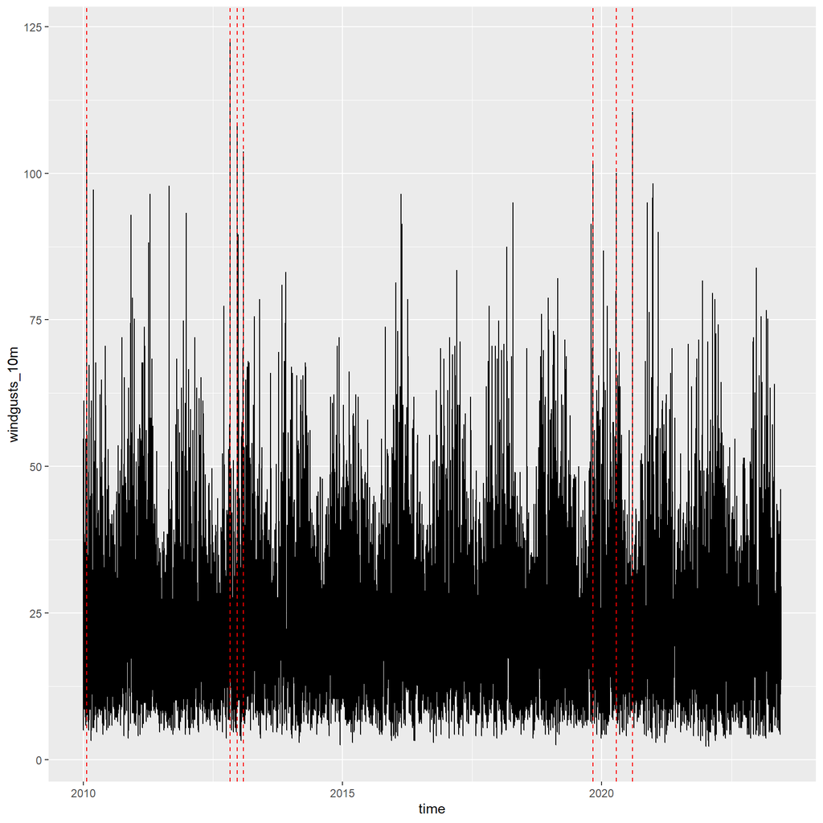

```r
keyDates <- nycTemp %>%
    filter(windspeed_10m>60 | windgusts_10m>100) %>%
    pull(date) %>%
    unique()
nycTemp %>%
    ggplot(aes(x=time)) +
    geom_line(aes(y=windgusts_10m)) +
    geom_vline(xintercept = lubridate::ymd_hm(paste0(keyDates, "T12:00")), color="red", lty=2)
```

Random variables and additional explanatory variables are created, and test-train data are split:

```r
# Add random variables to dataset, then split in to test and train
set.seed(23100415)
nycTempRand <- nycTemp %>%
    mutate(pct_0005=sample(0:5, size=nrow(.), replace=TRUE),
           pct_0025=sample(0:25, size=nrow(.), replace=TRUE),
           pct_0100=sample(0:100, size=nrow(.), replace=TRUE),
           pct_0250=sample(0:250, size=nrow(.), replace=TRUE),
           pct_0500=sample(0:500, size=nrow(.), replace=TRUE),
           pct_1000=sample(0:1000, size=nrow(.), replace=TRUE),
           pct_2500=sample(0:2500, size=nrow(.), replace=TRUE),
           pct_5000=sample(0:5000, size=nrow(.), replace=TRUE),
           tod=ifelse(hour>=7 & hour<=18, "Day", "Night"),
           season=case_when(month %in% c("Mar", "Apr", "May") ~ "Spring",
                            month %in% c("Jun", "Jul", "Aug") ~ "Summer",
                            month %in% c("Sep", "Oct", "Nov") ~ "Fall",
                            month %in% c("Dec", "Jan", "Feb") ~ "Winter",
                            TRUE~"typo"
                            ),
           todSeason=paste0(season, "-", tod),
           tod=factor(tod, levels=c("Day", "Night")),
           season=factor(season, levels=c("Spring", "Summer", "Fall", "Winter")),
           todSeason=factor(todSeason,
                            levels=paste0(rep(c("Spring", "Summer", "Fall", "Winter"), each=2),
                                          "-",
                                          c("Day", "Night")
                                          )
                            )
           )
nycTempRand %>% count(tod)
```

```
## # A tibble: 2 × 2
##   tod       n
##   <fct> <int>
## 1 Day   58968
## 2 Night 58968
```